# R Notebook

## Applying Transportability Methods to Assess the Respiratory Health Impacts of Wildfire Smoke: Insights from the 2018 California Wildfires

### Load packages, functions and data

```r
# Load packages
library(tidyverse)
library(table1)
library(SuperLearner)
library(ggpubr)
library(grid)
library(ggplot2)
library(dplyr)
library(patchwork)
library(tableone)
library(survey)
library(cobalt)
library(WeightIt)
library(SuperLearner)
library(ggpubr)
library(purrr)

# Load functions
source("functions.R")

# Set seed
set.seed(10149101)
```

```r
# Read data
data <- read_wildfire_data()

# Create exposed county data set
exposed_data <- data |>
    filter(Smokebin == 1) |>
    mutate(resp_prop = resp/total.pop,
           date = ymd(paste0(year, "/", month, "/", day)))
```

### Descriptive analysis

#### Table 2: descriptive statistics

```r
descriptive_data <- exposed_data |>
    mutate(tmax = structure(tmax, label = "Maximum temperature"),
           prec = structure(prec, label = "Precipitation"),
           hum = structure(hum, label = "Relative humidity"),
           shrtwv_rad = structure(shrtwv_rad, label = "Shortwave radiation"),
           wind = structure(wind, label = "Wind velocity"),
           exp_day = factor(exp_day, levels = c(0,1), labels = c("Before smoke exposure", "After smoke exposure")))

table1(~ tmax + prec + hum + shrtwv_rad + wind | exp_day,
       overall = c(left = "Total"),
       data = descriptive_data)
```

|  | Total (N=2268) | Before smoke exposure (N=1512) | After smoke exposure (N=756) |
| --- | --- | --- | --- |
| Maximum temperature |  |  |  |
| Mean (SD) | 296 (5.56) | 299 (3.62) | 290 (3.19) |
| Median [Min, Max] | 297 [281, 309] | 299 [288, 309] | 290 [281, 298] |
| Precipitation |  |  |  |
| Mean (SD) | 1.56 (5.32) | 0.236 (1.55) | 4.20 (8.35) |
| Median [Min, Max] | 0 [0, 50.3] | 0 [0, 23.2] | 0 [0, 50.3] |
| Relative humidity |  |  |  |
| Mean (SD) | 0.00551 (0.00221) | 0.00586 (0.00197) | 0.00481 (0.00247) |
| Median [Min, Max] | 0.00555 [0.000827, 0.0125] | 0.00574 [0.00149, 0.0125] | 0.00496 [0.000827, 0.00955] |
| Shortwave radiation |  |  |  |
| Mean (SD) | 166 (58.0) | 196 (40.3) | 106 (38.3) |
| Median [Min, Max] | 162 [23.3, 273] | 197 [82.6, 273] | 120 [23.3, 164] |
| Wind velocity |  |  |  |
| Mean (SD) | 3.16 (1.59) | 3.29 (1.43) | 2.90 (1.84) |
| Median [Min, Max] | 2.82 [0.563, 9.97] | 2.96 [0.733, 9.15] | 2.28 [0.563, 9.97] |

#### Figure A1: generate scatter plots by county with simple level change model prediction overlay (without time-varying confounders)

Initial version:

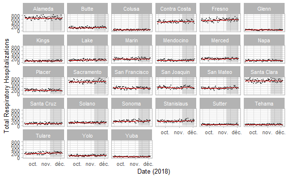

```r
plot_data <- exposed_data |>
  group_by(countyname) |>
  mutate(resp_fitted = predict(glm(resp ~ offset(log(total.pop)) + exp_day + time_unit, family = quasipoisson),type = "response")) |>
  ungroup()

plot_data |> ggplot(aes(x = date, y = resp)) +
  geom_point(alpha = 5/10, size = 0.5) +
  geom_line(aes(x = date, y = resp_fitted), color = "red") +
  annotate('rect',
           xmin=ymd("2018-11-08"),
           xmax=ymd("2018-12-05"),
           ymin=min(exposed_data$resp),
           ymax=max(exposed_data$resp),
           alpha=.2) +
  theme_light() +
  facet_wrap(vars(countyname)) +
  labs(x = "Date (2018)",
       y = "Total Respiratory Hospitalizations")
```

A version that provides a better understanding of the dynamics:

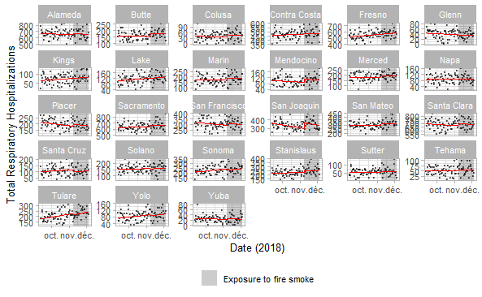

```r
plot_data |> ggplot(aes(x = date, y = resp)) +
  geom_rect(data = data.frame(xmin = ymd("2018-11-08"),
                              xmax = ymd("2018-12-05"),
                              ymin = -Inf,
                              ymax = Inf),
            aes(xmin = xmin,
                xmax = xmax,
                ymin = ymin,
                ymax = ymax,
                fill = "Exposure to fire smoke"),
            inherit.aes = FALSE,
            alpha = 0.2) +
  geom_point(alpha = 5/10, size = 0.5) +
  geom_line(aes(x = date, y = resp_fitted), color = "red") +
  scale_fill_manual(name = NULL, values = c("Exposure to fire smoke" = "black")) +
  theme_light() +
  theme(legend.position = "bottom") +
  facet_wrap(vars(countyname), scales = "free_y") +
  labs(x = "Date (2018)", y = "Total Respiratory Hospitalizations")
```

### Effect of wildfire exposure for each county

#### Estimate effects

```r
exposed_county_effects <- t(sapply(unique(exposed_data$countyname), function(s) {
    county_ind <- which(exposed_data$countyname == s)
    s_estimate <- estimate_effect(county_ind, count = TRUE)
    return(s_estimate)
}))
exposed_county_effects <- tibble::rownames_to_column(data.frame(exposed_county_effects), "county")
colnames(exposed_county_effects) <- c("county", "estimate", "lower_ci", "upper_ci")
```

#### Figure 1: plot the effect estimates

Initial version:

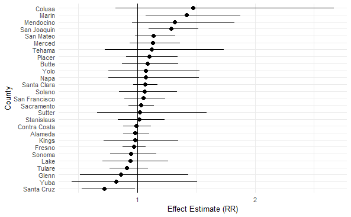

```r
exposed_county_effects |>
    ggplot(aes(x = reorder(county, estimate),
               y = estimate)) +
    geom_pointrange(aes(ymin = lower_ci, ymax = upper_ci)) +
    geom_hline(yintercept = 1) +
    coord_flip() +
    labs(x = "County", y = "Effect Estimate (RR)") +
    theme_minimal()
```

Another version of the graph:

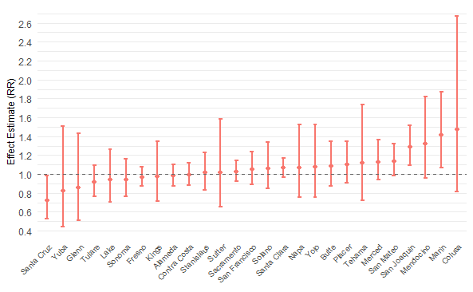

```r
exposed_county_effects |>
  ggplot(aes(x = reorder(county, estimate), y = estimate)) +
  geom_errorbar( # Confidence intervals
    aes(ymin = lower_ci, ymax = upper_ci),
    color = "#F8766D",
    linewidth = 0.8,
    width = 0.25
  ) +
  geom_point(
    color = "#F8766D",
    size = 1.8
  ) +
  geom_hline(
    yintercept = 1,
    linetype = "dashed",
    color = "grey40"
  ) +
  labs(
    x = NULL,
    y = "Effect Estimate (RR)"
  ) +
  scale_y_continuous(
    breaks = seq(0, 3, by = 0.2)
  ) +
  theme_minimal(base_size = 13) +
  theme(
    axis.text.x = element_text(
      angle = 45,
      hjust = 1,
      vjust = 1,
      size = 8
    ),
    axis.title.y = element_text(size = 10),
    panel.grid.major.x = element_blank()
  )
```

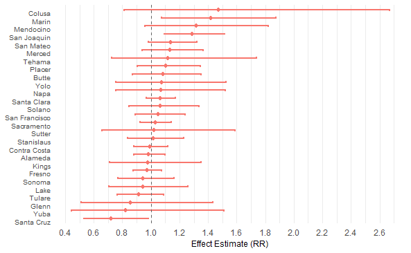

```r
exposed_county_effects |>
  ggplot(aes(x = reorder(county, estimate), y = estimate)) +
  geom_errorbar(
    aes(ymin = lower_ci, ymax = upper_ci),
    color = "#F8766D",
    linewidth = 0.8,
    width = 0.25
  ) +
  geom_point(
    color = "#F8766D",
    size = 1.8
  ) +
  geom_hline(
    yintercept = 1,
    linetype = "dashed",
    color = "grey40"
  ) +
  labs(
    x = NULL,
    y = "Effect Estimate (RR)"
  ) +
  scale_y_continuous(
    breaks = seq(0, 3, by = 0.2)
  ) +
  theme_minimal(base_size = 13) +
  theme(
    axis.text.y = element_text(
      angle = 0,
      hjust = 1,
      vjust = 1,
      size = 8
    ),
    axis.title.x = element_text(size = 10),
    panel.grid.major.y = element_blank()
  )+
  coord_flip()
```

### Transport county-level effect estimates

```r
exposed_county_effects <- exposed_county_effects |>
    mutate(type = "Observed")
```

#### Study all counties simultaneously.

##### Estimate the transported effect for each county using all remaining counties

```r
# transport_all <- t(sapply(unique(exposed_data$countyname), function(s) {
#   county_1 <- unique(exposed_data$countyname)[!(unique(exposed_data$countyname) == s)]
#   effect <- transport_iosw(county_1 = county_1, county_0 = s)
#   return(effect)
# }))
#
# transport_all <- as.data.frame(apply(transport_all, 2, unlist)) |>
#   mutate(county = rep(rownames(transport_all), each = 2),
#          type = case_when(type == "Transported (logistic regression)" ~ "Transported - all (logistic regression)",
#                           type == "Transported (SuperLearner)" ~ "Transported - all (SuperLearner)"),
#          across(c(estimate, lower_ci, upper_ci), as.numeric))
#
# save(transport_all, file="transport_all.rds")

load(file="transport_all.rds")
```

##### Estimate the transported effect for each county using 50% of remaining counties (randomly selected)

```r
# transport_half <- t(sapply(unique(exposed_data$countyname), function(s) {
#   other_counties <- unique(exposed_data$countyname)[!(unique(exposed_data$countyname) == s)]
#   county_1 <- sample(other_counties, 0.5*length(other_counties), replace = F)
#   effect <- transport_iosw(county_1 = county_1, county_0 = s)
#   return(effect)
# }))
#
# transport_half <- as.data.frame(apply(transport_half, 2, unlist)) |>
#   mutate(county = rep(rownames(transport_half), each = 2),
#          type = case_when(type == "Transported (logistic regression)" ~ "Transported - 50% (logistic regression)",
#                           type == "Transported (SuperLearner)" ~ "Transported - 50% (SuperLearner)"),
#          across(c(estimate, lower_ci, upper_ci), as.numeric))
#
# save(transport_half, file="transport_half.rds")

load("transport_half.rds")
```

##### Figure A2: Observed and transported effect estimates for each exposed county

Initial version:

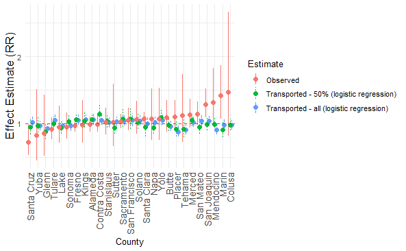

```r
# Order the counties according to the estimated effect.
county_order <- exposed_county_effects |>
  arrange(estimate) |>
  pull(county) |>
  unique()

bind_rows(transport_all, transport_half, exposed_county_effects) |>
  filter(type %in% c("Observed",
                     "Transported - all (logistic regression)",
                     "Transported - 50% (logistic regression)")) |>
  mutate(county = factor(county, levels = county_order)) |>
  ggplot(aes(x = county,
             y = estimate,
             color = type,
             linetype = type)) +
  geom_pointrange(aes(ymin = lower_ci, ymax = upper_ci),
                  position = position_dodge(0.7)) +
  geom_hline(yintercept = 1, linetype = "dashed", color = "grey40") +
  labs(x = "County",
       y = "Effect Estimate (RR)",
       linetype = "Estimate",
       color = "Estimate") +
  theme_minimal() +
  theme(
    axis.text.x = element_text(angle = 90, vjust = 0.5, hjust = 1, size = 12),
    axis.title.y = element_text(size = 14)
  )
```

Another version of the graph:

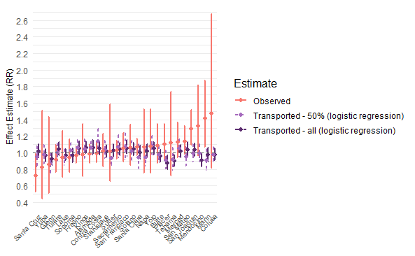

```r
# Shared position_dodge object to align interval brackets and points
pd <- position_dodge(width = 0.7)

bind_rows(transport_all, transport_half, exposed_county_effects) |>
  filter(type %in% c("Observed",
                     "Transported - all (logistic regression)",
                     "Transported - 50% (logistic regression)")) |>
  mutate(county = factor(county, levels = county_order)) |>
  ggplot(aes(x = county,
             y = estimate,
             color = type,
             linetype = type)) +
  geom_errorbar(
    aes(ymin = lower_ci, ymax = upper_ci),
    linewidth = 0.8,
    width = 0.3,
    position = pd
  ) +
  geom_point(
    size = 1.8,
    position = pd
  ) +
  geom_hline(
    yintercept = 1,
    linetype = "dashed",
    color = "grey40"
  ) +
  scale_color_manual(
    values = c(
      "Observed" = "#F8766D",
      "Transported - all (logistic regression)" = "#5B2C6F",
      "Transported - 50% (logistic regression)" = "#A569BD"
    )
  ) +
  scale_y_continuous(
    breaks = seq(0, 3, by = 0.2)
  ) +
  labs(
    x = NULL,
    y = "Effect Estimate (RR)",
    color = "Estimate",
    linetype = "Estimate"
  ) +
  theme_minimal(base_size = 13) +
  theme(
    axis.text.x = element_text(
      angle = 45,
      hjust = 1,
      vjust = 1,
      size = 8
    ),
    axis.title.y = element_text(size = 10),
    panel.grid.major.x = element_blank()
  )
```

Another version of the graph:

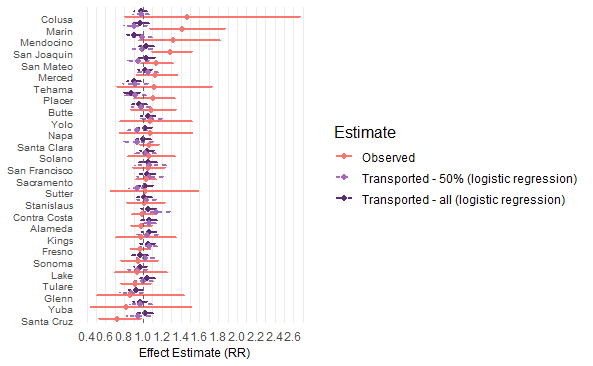

```r
bind_rows(transport_all, transport_half, exposed_county_effects) |>
  filter(type %in% c("Observed",
                     "Transported - all (logistic regression)",
                     "Transported - 50% (logistic regression)")) |>
  mutate(county = factor(county, levels = county_order)) |>
  ggplot(aes(x = county, y = estimate, color = type, linetype = type)) +
  geom_errorbar(
    aes(ymin = lower_ci, ymax = upper_ci),
    linewidth = 0.8,
    width = 0.3,
    position = pd
  ) +
  geom_point(
    size = 1.8,
    position = pd
  ) +
  geom_hline(
    yintercept = 1,
    linetype = "dashed",
    color = "grey40"
  ) +
  scale_color_manual(
    values = c(
      "Observed" = "#F8766D",
      "Transported - all (logistic regression)" = "#5B2C6F",
      "Transported - 50% (logistic regression)" = "#A569BD"
    )
  ) +
  scale_y_continuous(
    breaks = seq(0, 3, by = 0.2)
  ) +
  labs(
    x = NULL,
    y = "Effect Estimate (RR)",
    color = "Estimate",
    linetype = "Estimate"
  ) +
  theme_minimal(base_size = 13) +
  theme(
    axis.text.y = element_text(
      angle = 0,
      hjust = 1,
      vjust = 1,
      size = 8
    ),
    axis.title.x = element_text(size = 10),
    panel.grid.major.y = element_blank()
  )+
  coord_flip()
```

#### From the 5 counties with the greatest impact to San Joaquin

```r
top_5_counties <- c("Colusa", "Marin", "Mendocino", "San Mateo", "Merced")
sj_observed <- filter(exposed_county_effects, county == "San Joaquin")
```

##### Estimate the transported effects for each of Colusa, Marin, Mendocino, San Mateo, and Merced to San Joaquin

```r
transport_pairwise <- t(sapply(top_5_counties, function(s) transport_iosw(county_1 = s, county_0 = "San Joaquin")))
transport_pairwise <- as.data.frame(apply(transport_pairwise, 2, unlist)) |>
  mutate(county = paste0(rep(rownames(transport_pairwise), each = 2), " to ", "San Joaquin"),
         across(c(estimate, lower_ci, upper_ci), as.numeric)) |>
  bind_rows(sj_observed)
```

##### Estimate the transported effect for Colusa, Marin, Mendocino, San Mateo, and Merced to San Joaquin

```r
transport_jointly <- transport_iosw(top_5_counties, "San Joaquin")
transport_jointly <- sj_observed |>
    dplyr::select(-county) |>
    bind_rows(transport_jointly)
```

#### Figure 2: From the 5 counties with the greatest impact to San Joaquin

Initial version:

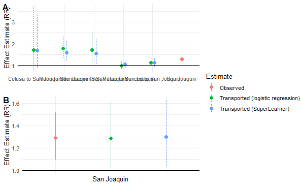

```r
fig_2A <- transport_pairwise %>%
  ggplot(aes(x = factor(county, level = unique(county)),
             y = estimate,
             color = type,
             linetype = type)) +
  geom_pointrange(aes(ymin = lower_ci, ymax = upper_ci),
                  position = position_dodge(0.25)) +
  geom_hline(yintercept = 1) +
  labs(x = "", y = "Effect Estimate (RR)", linetype = "") +
  theme_minimal() +
  labs(color = "Estimate", linetype = "Estimate")

fig_2B <- transport_jointly %>%
  ggplot(aes(x = type,
             y = estimate,
             color = type, linetype = type)) +
  geom_pointrange(aes(ymin = lower_ci, ymax = upper_ci),
                  position = position_dodge(0.25)) +
  geom_hline(yintercept = 1) +
  labs(x = "San Joaquin", y = "Effect Estimate (RR)") +
  theme_minimal() +
  theme(axis.text.x = element_blank()) +
  labs(color = "Estimate", linetype = "Estimate")

ggarrange(fig_2A, fig_2B,
                   nrow = 2,
                   labels = c("A", "B"),
                   common.legend = TRUE,
                   legend = "right")
```

Another version of the graph:

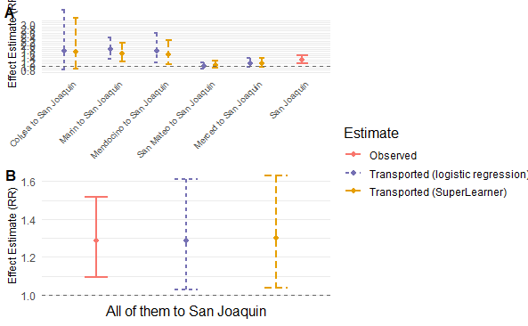

```r
pd <- position_dodge(width = 0.5)

custom_colors <- c(
  "Observed" = "#F8766D",
  "Transported (logistic regression)" = "#7570B3",
  "Transported (SuperLearner)" = "#E69F00"
)

fig_2A <- transport_pairwise |>
  ggplot(aes(x = factor(county, levels = unique(county)),
             y = estimate,
             color = type,
             linetype = type)) +
  geom_errorbar(
    aes(ymin = lower_ci, ymax = upper_ci),
    linewidth = 0.8,
    width = 0.25,
    position = pd
  ) +
  geom_point(
    size = 1.8,
    position = pd
  ) +
  geom_hline(
    yintercept = 1,
    linetype = "dashed",
    color = "grey40"
  ) +
  scale_color_manual(values = custom_colors) +
  scale_y_continuous(breaks = seq(0, 3, by = 0.2)) +
  labs(
    x = NULL,
    y = "Effect Estimate (RR)",
    color = "Estimate",
    linetype = "Estimate"
  ) +
  theme_minimal(base_size = 13) +
  theme(
    axis.text.x = element_text(angle = 45, hjust = 1, vjust = 1, size = 8),
    axis.title.y = element_text(size = 10),
    panel.grid.major.x = element_blank()
  )

fig_2B <- transport_jointly |>
  ggplot(aes(x = type,
             y = estimate,
             color = type,
             linetype = type)) +
  geom_errorbar(
    aes(ymin = lower_ci, ymax = upper_ci),
    linewidth = 0.8,
    width = 0.25,
    position = pd
  ) +
  geom_point(
    size = 1.8,
    position = pd
  ) +
  geom_hline(
    yintercept = 1,
    linetype = "dashed",
    color = "grey40"
  ) +
  scale_color_manual(values = custom_colors) +
  scale_y_continuous(breaks = seq(0, 3, by = 0.2)) +
  labs(
    x = "All of them to San Joaquin",
    y = "Effect Estimate (RR)",
    color = "Estimate",
    linetype = "Estimate"
  ) +
  theme_minimal(base_size = 13) +
  theme(
    axis.text.x = element_blank(),
    axis.title.y = element_text(size = 10),
    panel.grid.major.x = element_blank()
  )

ggarrange(
  fig_2A, fig_2B,
  nrow = 2,
  labels = c("A", "B"),
  common.legend = TRUE,
  legend = "right"
)
```

Another version of the graph:

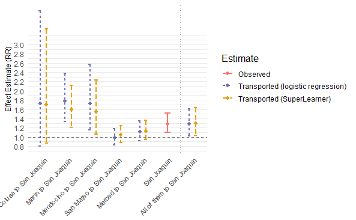

```r
# Merging of datasets
combined_transport <- bind_rows(
  transport_pairwise,
  transport_jointly[2:3,] |> mutate(county = "All of them to San Joaquin")
) |>
  mutate(
    county = factor(county, levels = c(unique(transport_pairwise$county),
                                       "All of them to San Joaquin"))
  )

pd <- position_dodge(width = 0.5)
custom_colors <- c("#F8766D", "#7570B3", "#E69F00")

combined_transport |>
  ggplot(aes(x = county, y = estimate, color = type, linetype = type)) +
  geom_vline(
    xintercept = length(unique(transport_pairwise$county)) + 0.5,
    linetype = "dotted",
    color = "grey60",
    linewidth = 0.6
  ) +
  geom_errorbar(
    aes(ymin = lower_ci, ymax = upper_ci),
    linewidth = 0.8,
    width = 0.25,
    position = pd
  ) +
  geom_point(
    size = 1.8,
    position = pd
  ) +
  geom_hline(
    yintercept = 1,
    linetype = "dashed",
    color = "grey40"
  ) +
  scale_color_manual(values = custom_colors) +
  scale_y_continuous(breaks = seq(0, 3, by = 0.2)) +
  labs(
    x = NULL,
    y = "Effect Estimate (RR)",
    color = "Estimate",
    linetype = "Estimate"
  ) +
  theme_minimal(base_size = 13) +
  theme(
    axis.text.x = element_text(angle = 45, hjust = 1, vjust = 1, size = 9),
    axis.title.y = element_text(size = 10),
    panel.grid.major.x = element_blank()
  )
```

### Can an effect be observed starting from conditions with no effect, and vice versa?

```r
top_counties <- c(top_5_counties, "San Joaquin")
no_effect_counties <- c("Fresno", "Kings", "Alameda", "Contra Costa", "Stanislaus", "Sacramento")
```

#### From counties with an effect or no effect to counties with effect:

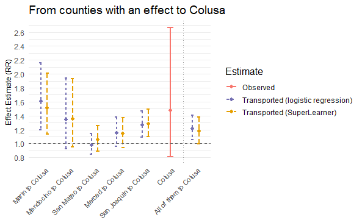

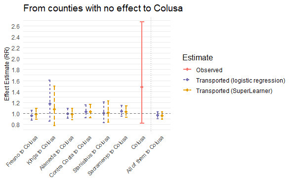

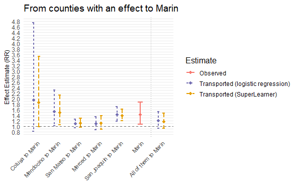

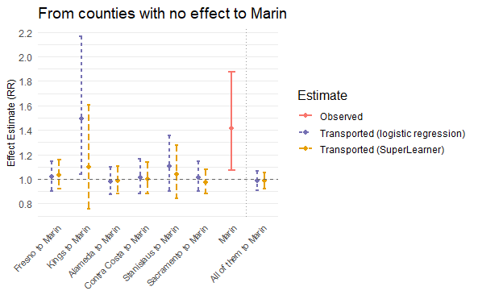

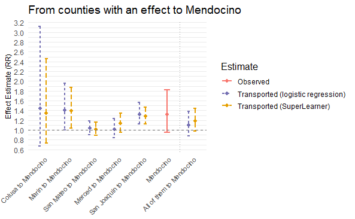

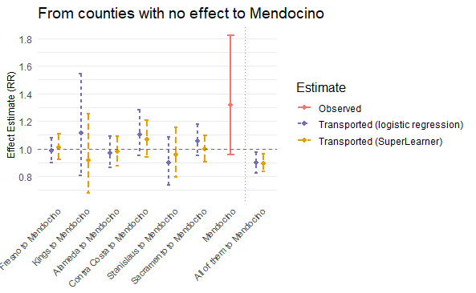

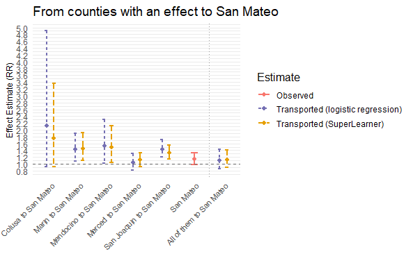

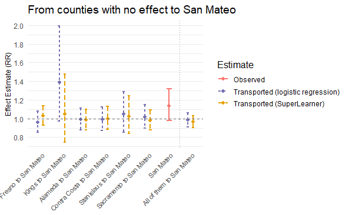

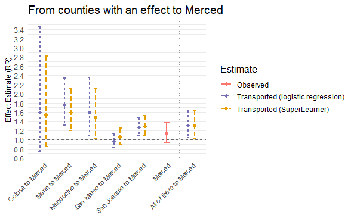

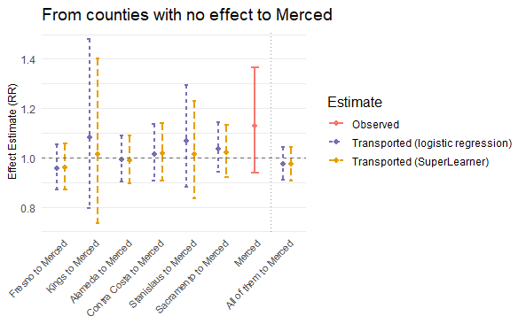

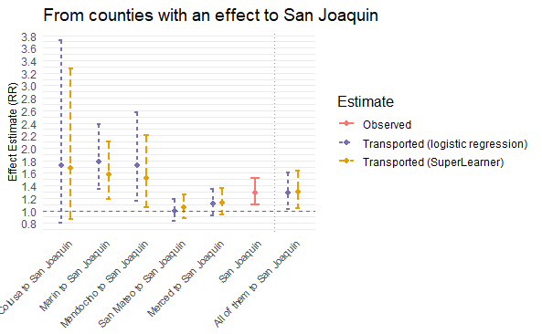

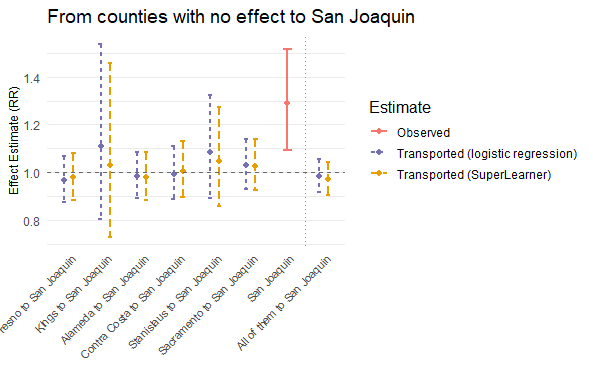

```r
for(county_0 in top_counties){

  counties_1 <- top_counties[-which(top_counties==county_0)]

  transport_analysis(county_0, counties_1, paste0("From counties with an effect to ", county_0))

  counties_1 <- no_effect_counties

  transport_analysis(county_0, counties_1,  paste0("From counties with no effect to ", county_0))
}
```

#### From counties with an effect or no effect to counties with no effect

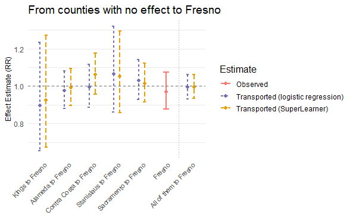

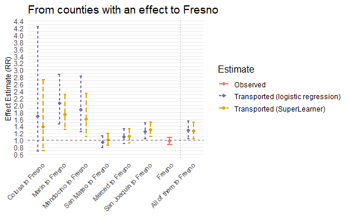

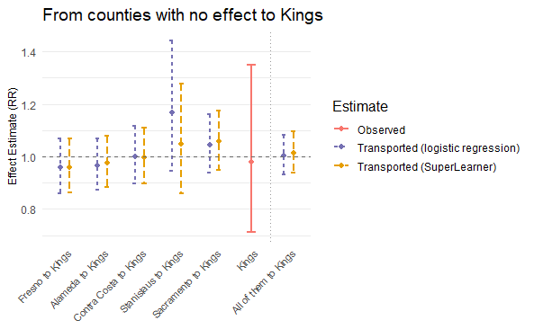

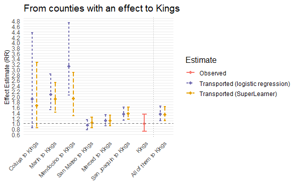

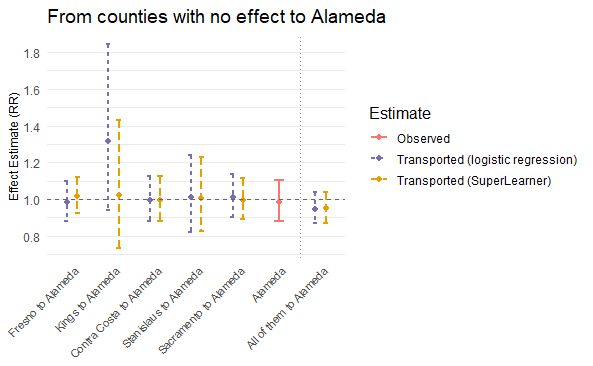

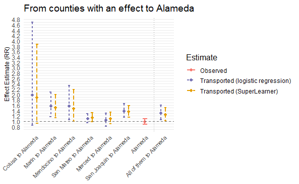

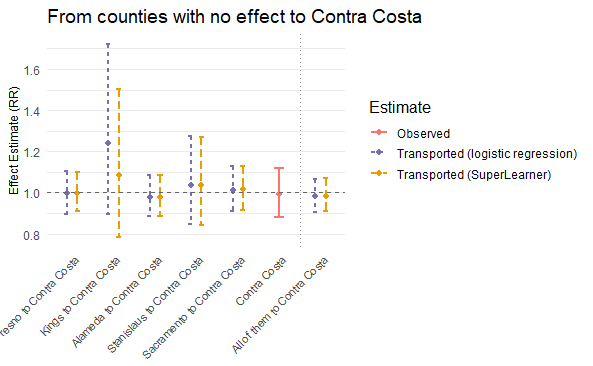

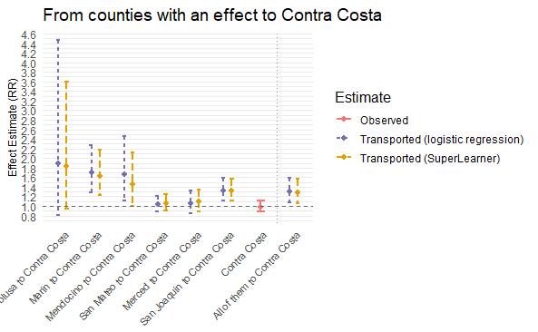

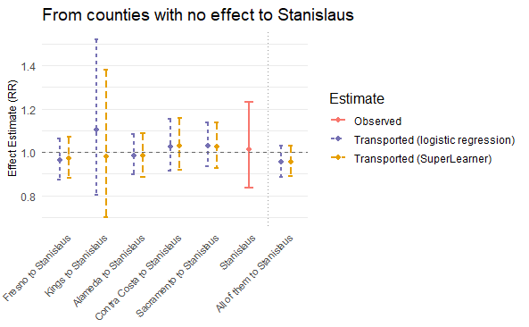

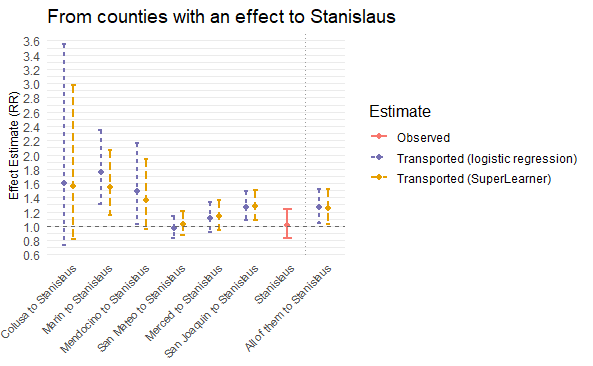

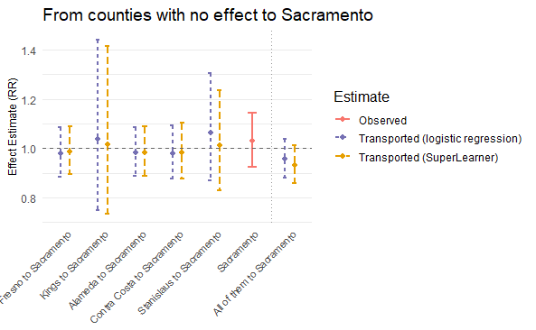

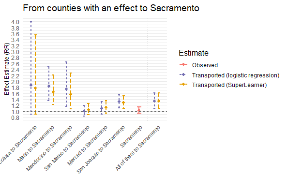

```r
for(county_0 in no_effect_counties){

  counties_1 <- no_effect_counties[-which(no_effect_counties==county_0)]

  transport_analysis(county_0, counties_1, paste0("From counties with no effect to ", county_0))

  counties_1 <- top_counties

  transport_analysis(county_0, counties_1,  paste0("From counties with an effect to ", county_0))
}
```